# Age of Wonder data summary

Recruitment and data collection to end of July 2026

The following report gives a breakdown of Age of Wonder (AoW) recruitment volumes and patterns over the years of the study, with counts of completed datasets of each type.

Please note the following omissions:

- Surveys have not been processed for the pilot year (2021-22) so are not counted here.
- CKAT is not included as work to prepare this dataset is ongoing.
- Only recruitment and data collection from Y8 to Y10 is included. Data collected in older age groups will be released separately after the 2025-26 academic year.

# Headline counts of individuals

Number of individuals recruited to Age of Wonder and those with some data. Additionally, how many of those are in the original BiB cohort.

|  | All of AoW | BiB participants |
| --- | --- | --- |
| Total number of individuals recruited | 24198 | 5667 |
| Number with any data at any time | 19329 | 4695 |
| Number with a survey at any time | 18797 | 4554 |
| Number with a health measure at any time | 7793 | 2653 |

# All AoW recruits

### AoW Y8-10 class lists received

All recruited participants to date, i.e. full class lists received from schools across Y8-10 in each recruitment year, excluding any late withdrawals.

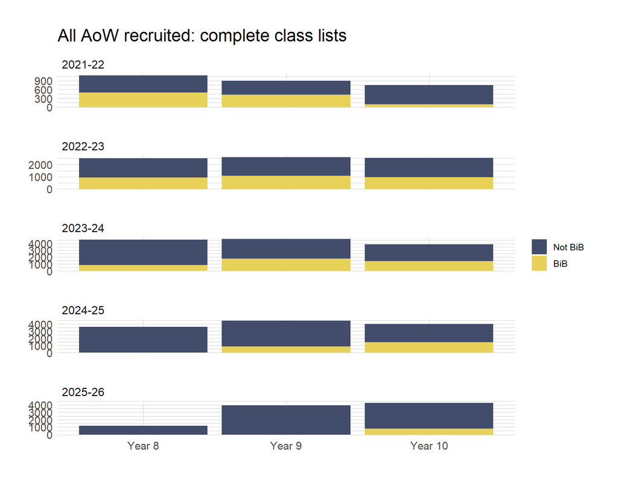

### Participants with data

Number of participants with completed datasets of each type across Y8-10 in each recruitment year. The plot below reflects data in the module 25 dataset released in 2026. This includes survey responses from all years where questions were carried forward. So, it is a longitudinal dataset containing responses to all questions from module 25 and all responses to matching questions from previous modules in previous years.

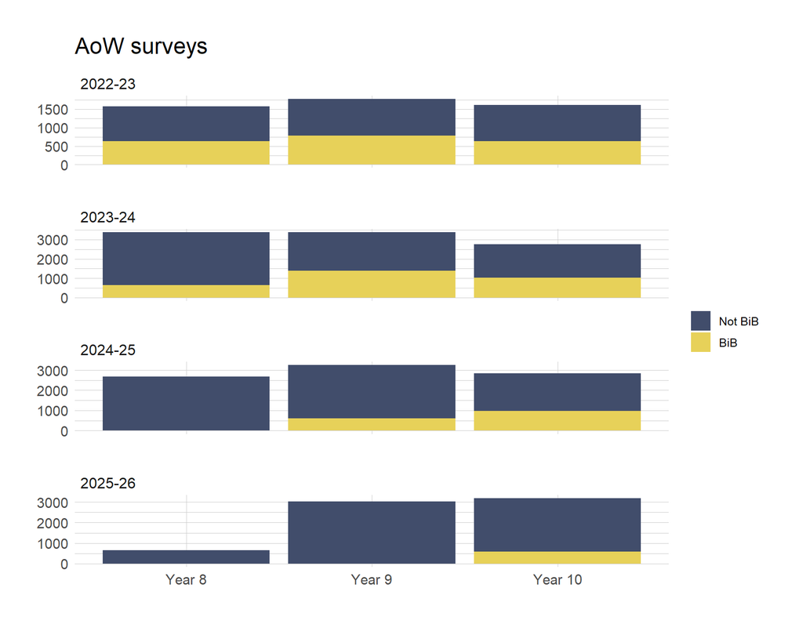

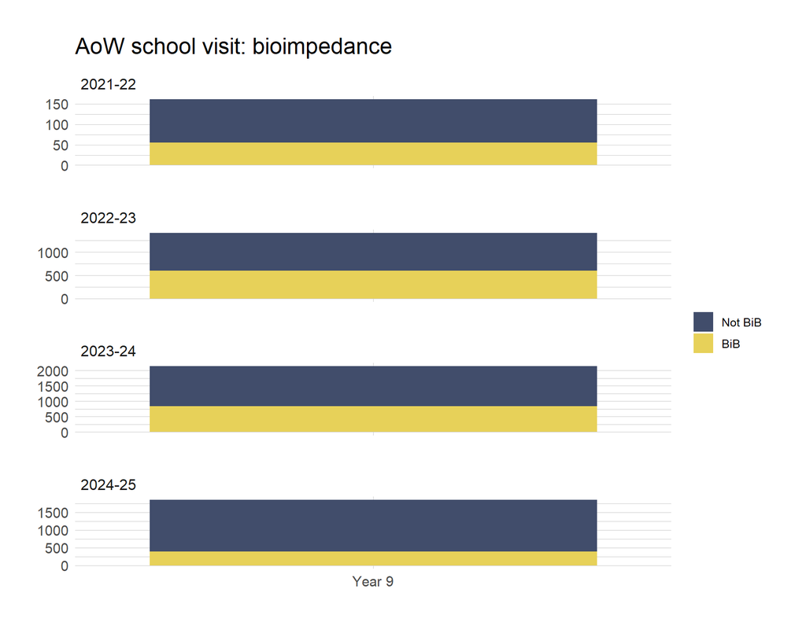

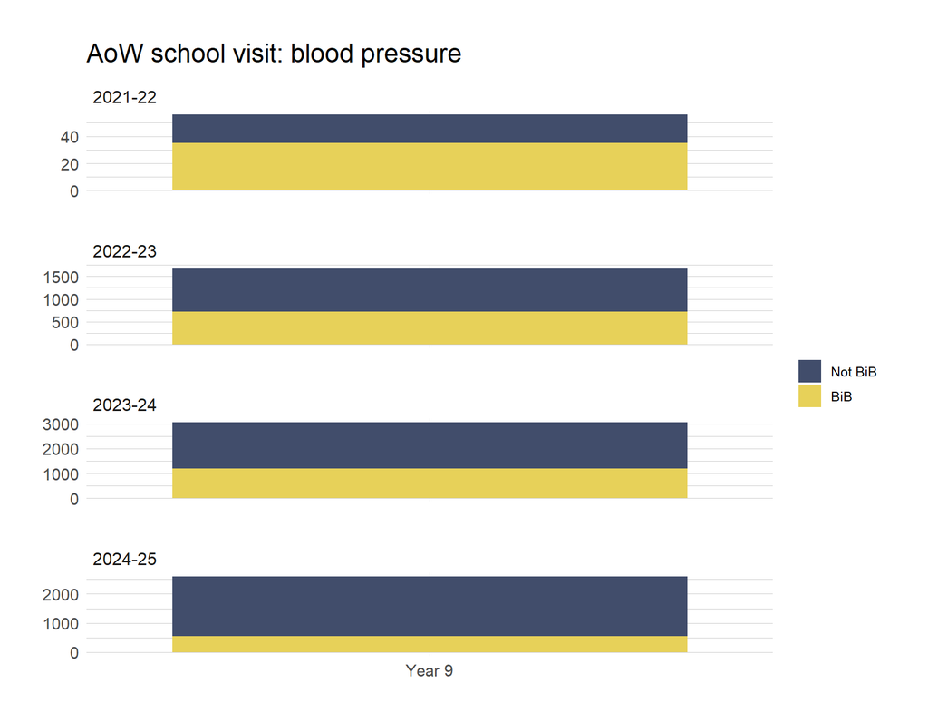

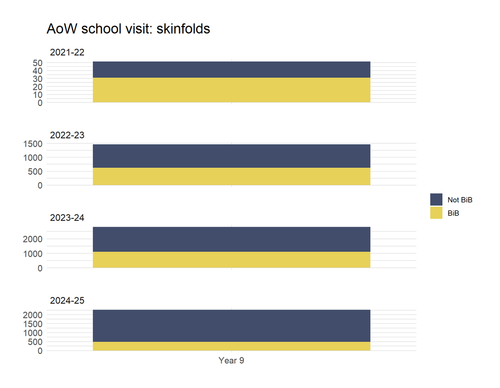

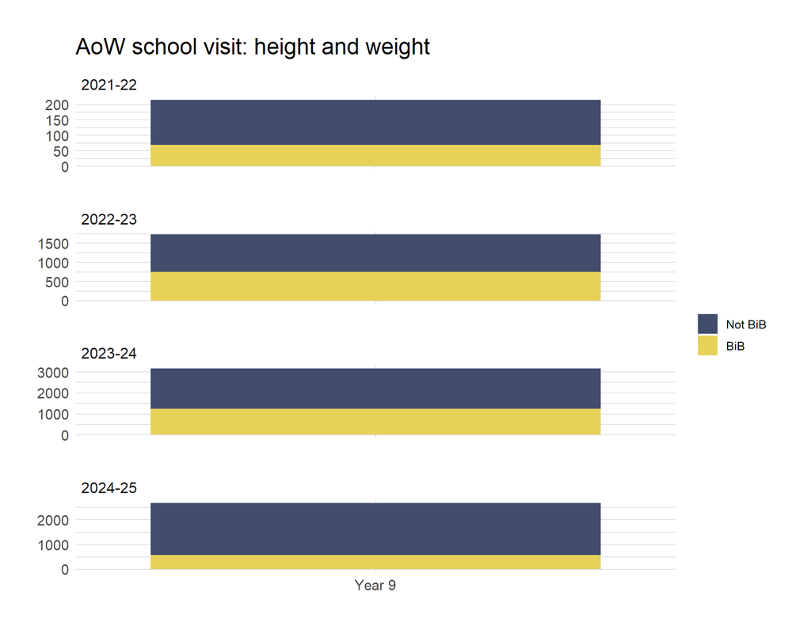

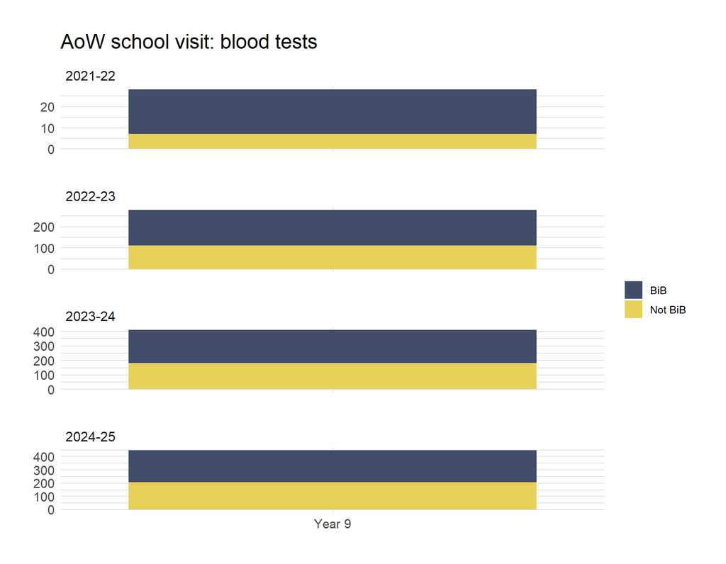

### Repeat recruits

The following tables break down the number of participants recruited in each year by whether or not they are recruited in more than one year (“repeat recruits”). The second table “Broken down by recruitment year” gives counts by specific pattern of repeat recruitments over a participant’s year group at recruitment.

The cohort is split by their 2022 year group. We are excluding the pilot year in these counts (2021-22).

Totals by year group subcohort

| Year group in 2022 | Any repeat recruits | Any repeat recruits | Total recruits | Total recruits |
| --- | --- | --- | --- | --- |
| Year 5 | 0 | (0 BiB) | 1192 | (0 BiB) |
| Year 6 | 2913 | (0 BiB) | 4612 | (0 BiB) |
| Year 7 | 4539 | (896 BiB) | 5756 | (1023 BiB) |
| Year 8 | 3836 | (1475 BiB) | 5648 | (2032 BiB) |
| Year 9 | 2035 | (816 BiB) | 4442 | (1639 BiB) |
| Year 10 | 0 | (0 BiB) | 2548 | (973 BiB) |
| TOTAL | 13323 | (3187 BiB) | 24198 | (5667 BiB) |

Broken down by recruitment year

| Year group in 2022 | Recruited in year Year 8 | Recruited in year Year 9 | Recruited in year Year 10 | Total |  |  |  |
| --- | --- | --- | --- | --- | --- | --- | --- |
| Year 5 | Yes | - | - |  |  | 1192 | (0 BiB) |
| Year 6 | - | Yes | - | 1008 | (0 BiB) |  |  |
|  | Yes | - | - | 691 | (0 BiB) |  |  |
|  | Yes | Yes | - | 2913 | (0 BiB) |  |  |
| Year 7 | - | - | Yes | 424 | (23 BiB) |  |  |
|  | - | Yes | - | 135 | (25 BiB) |  |  |
|  | - | Yes | Yes | 668 | (147 BiB) |  |  |
|  | Yes | - | - | 658 | (79 BiB) |  |  |
|  | Yes | - | Yes | 246 | (57 BiB) |  |  |
|  | Yes | Yes | - | 680 | (127 BiB) |  |  |
|  | Yes | Yes | Yes | 2945 | (565 BiB) |  |  |
| Year 8 | - | - | Yes | 605 | (98 BiB) |  |  |
|  | - | Yes | - | 843 | (336 BiB) |  |  |
|  | - | Yes | Yes | 1708 | (677 BiB) |  |  |
|  | Yes | - | - | 364 | (123 BiB) |  |  |
|  | Yes | - | Yes | 45 | (9 BiB) |  |  |
|  | Yes | Yes | - | 445 | (131 BiB) |  |  |
|  | Yes | Yes | Yes | 1638 | (658 BiB) |  |  |
| Year 9 | - | - | Yes | 1847 | (572 BiB) |  |  |
|  | - | Yes | - | 560 | (251 BiB) |  |  |
|  | - | Yes | Yes | 2035 | (816 BiB) |  |  |
| Year 10 | - | - | Yes | 2548 | (973 BiB) |  |  |

### Repeat survey responses

The following tables break down the number of participants with survey responses in each year by whether or not they have a survey response in more than one year (“repeat surveys”). The second table “Broken down by response year” gives counts by specific pattern of repeat survey reponses over a participant’s year group at recruitment.

The cohort is split by their 2022 year group. We are excluding the pilot year in these counts (2021-22).

Totals by year group subcohort

| Year group in 2022 | Any repeat surveys | Any repeat surveys | Total surveys | Total surveys |
| --- | --- | --- | --- | --- |
| Year 5 | 0 | (0 BiB) | 649 | (0 BiB) |
| Year 6 | 1925 | (0 BiB) | 3765 | (0 BiB) |
| Year 7 | 3354 | (666 BiB) | 4898 | (917 BiB) |
| Year 8 | 2384 | (956 BiB) | 4490 | (1693 BiB) |
| Year 9 | 1134 | (500 BiB) | 3382 | (1316 BiB) |
| Year 10 | 0 | (0 BiB) | 1613 | (628 BiB) |
| TOTAL | 8797 | (2122 BiB) | 18797 | (4554 BiB) |

Broken down by response year

| Year group in 2022 | Survey response in year Year 8 | Survey response in year Year 9 | Survey response in year Year 10 | Total |  |  |  |
| --- | --- | --- | --- | --- | --- | --- | --- |
| Year 5 | Yes | - | - |  |  | 649 | (0 BiB) |
| Year 6 | - | Yes | - | 1094 | (0 BiB) |  |  |
|  | Yes | - | - | 746 | (0 BiB) |  |  |
|  | Yes | Yes | - | 1925 | (0 BiB) |  |  |
| Year 7 | - | - | Yes | 505 | (55 BiB) |  |  |
|  | - | Yes | - | 329 | (62 BiB) |  |  |
|  | - | Yes | Yes | 678 | (142 BiB) |  |  |
|  | Yes | - | - | 710 | (134 BiB) |  |  |
|  | Yes | - | Yes | 438 | (109 BiB) |  |  |
|  | Yes | Yes | - | 672 | (135 BiB) |  |  |
|  | Yes | Yes | Yes | 1566 | (280 BiB) |  |  |
| Year 8 | - | - | Yes | 759 | (169 BiB) |  |  |
|  | - | Yes | - | 1127 | (485 BiB) |  |  |
|  | - | Yes | Yes | 1034 | (412 BiB) |  |  |
|  | Yes | - | - | 220 | (83 BiB) |  |  |
|  | Yes | - | Yes | 144 | (48 BiB) |  |  |
|  | Yes | Yes | - | 316 | (155 BiB) |  |  |
|  | Yes | Yes | Yes | 890 | (341 BiB) |  |  |
| Year 9 | - | - | Yes | 1611 | (527 BiB) |  |  |
|  | - | Yes | - | 637 | (289 BiB) |  |  |
|  | - | Yes | Yes | 1134 | (500 BiB) |  |  |
| Year 10 | - | - | Yes | 1613 | (628 BiB) |  |  |

# BiB participants only

### BiB participants in AoW with Growing Up surveys

Just the participants from the original BiB cohort recruited to AoW, and how many of them had a child survey (adult or child completed) from the Growing Up follow-up.

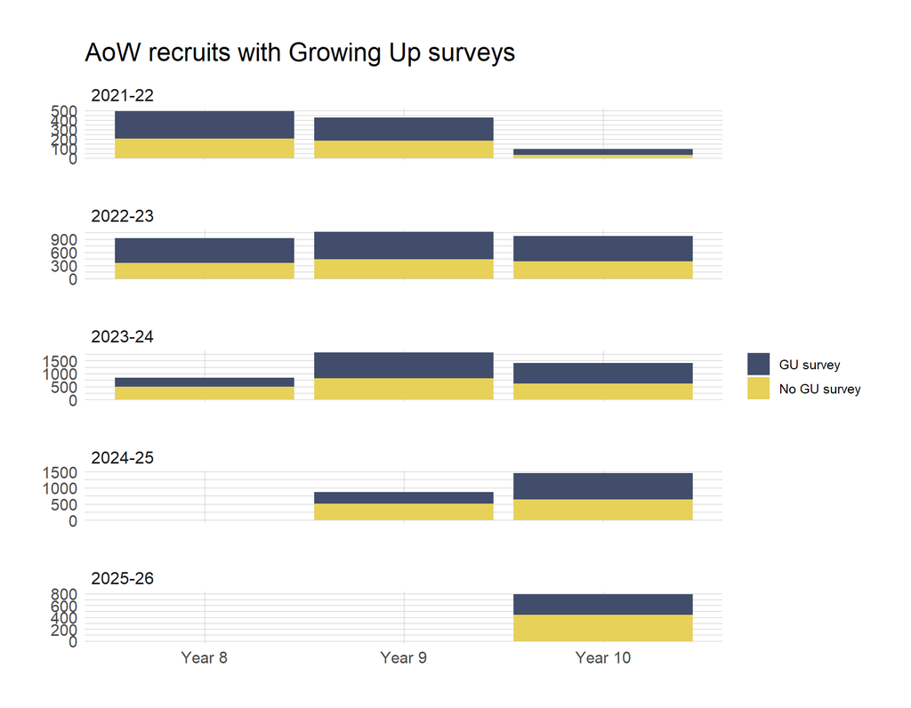

# Detailed tables

The following tables give detailed counts of participants with completed datasets of each type, split by the academic year of recruitment (which we call `recruitment_era`) and the year group they were in at the time.

### Participants received (total) and with data

| total | has_data | has_survey | has_measure | has_bloods | has_ckcog |
| --- | --- | --- | --- | --- | --- |
| 42249 | 31408 | 30061 | 7799 | 1133 | 5711 |

### Participants received (total) and with data, BiB only

| total | has_data | has_survey | has_measure | has_bloods | has_ckcog |
| --- | --- | --- | --- | --- | --- |
| 10109 | 7709 | 7297 | 2654 | 636 | 1809 |

### Participants received (unique) and with data

| total | has_data | has_survey | multi_survey | has_measure | has_bloods | has_ckcog |
| --- | --- | --- | --- | --- | --- | --- |
| 24198 | 19329 | 18797 | 8802 | 7793 | 1133 | 5710 |

### Participants received (unique) and with data, BiB only

| total | has_data | has_survey | multi_survey | has_measure | has_bloods | has_ckcog |
| --- | --- | --- | --- | --- | --- | --- |
| 5667 | 4695 | 4554 | 2122 | 2653 | 636 | 1809 |

### Participants received (total) and with data by year group

| year_group | total | has_data | has_survey | previous_survey | has_measure | has_bloods | has_ckcog |
| --- | --- | --- | --- | --- | --- | --- | --- |
| 8 | 11852 | 8278 | 8278 | 2 | 0 | 0 | 1 |
| 9 | 15646 | 12755 | 11408 | 5375 | 7799 | 1133 | 5710 |
| 10 | 14751 | 10375 | 10375 | 5887 | 0 | 0 | 0 |

### Participants received (total) and with data by year group, BiB only

| year_group | total | has_data | has_survey | previous_survey | has_measure | has_bloods | has_ckcog |
| --- | --- | --- | --- | --- | --- | --- | --- |
| 8 | 1751 | 1285 | 1285 | 0 | 0 | 0 | 0 |
| 9 | 3745 | 3213 | 2801 | 911 | 2654 | 636 | 1809 |
| 10 | 4613 | 3211 | 3211 | 1832 | 0 | 0 | 0 |

### Participants received (total) and with data by recruitment year

| recruitment_era | total | has_data | has_survey | previous_survey | has_measure | has_bloods | has_ckcog |
| --- | --- | --- | --- | --- | --- | --- | --- |
| 2022-23 | 7646 | 5231 | 4954 | 0 | 1755 | 279 | 846 |
| 2023-24 | 13104 | 10123 | 9503 | 2345 | 3241 | 408 | 2280 |
| 2024-25 | 12084 | 9197 | 8747 | 4310 | 2803 | 446 | 2585 |
| 2025-26 | 9415 | 6857 | 6857 | 4609 | 0 | 0 | 0 |

### Participants received (total) and with data by recruitment year, BiB only

| recruitment_era | total | has_data | has_survey | previous_survey | has_measure | has_bloods | has_ckcog |
| --- | --- | --- | --- | --- | --- | --- | --- |
| 2022-23 | 2965 | 2146 | 2044 | 0 | 758 | 168 | 328 |
| 2023-24 | 4034 | 3261 | 3078 | 996 | 1278 | 227 | 971 |
| 2024-25 | 2317 | 1716 | 1589 | 1216 | 618 | 241 | 510 |
| 2025-26 | 793 | 586 | 586 | 531 | 0 | 0 | 0 |

### Participants received (total) and with data by subcohort

| recruitment_era | year_group | total | has_data | has_survey | previous_survey | has_measure | has_bloods | has_ckcog |
| --- | --- | --- | --- | --- | --- | --- | --- | --- |
| 2022-23 | 8 | 2497 | 1570 | 1570 | 0 | 0 | 0 | 1 |
| 2022-23 | 9 | 2599 | 2048 | 1771 | 0 | 1755 | 279 | 845 |
| 2022-23 | 10 | 2550 | 1613 | 1613 | 0 | 0 | 0 | 0 |
| 2023-24 | 8 | 4546 | 3386 | 3386 | 0 | 0 | 0 | 0 |
| 2023-24 | 9 | 4659 | 3990 | 3370 | 1209 | 3241 | 408 | 2280 |
| 2023-24 | 10 | 3899 | 2747 | 2747 | 1136 | 0 | 0 | 0 |
| 2024-25 | 8 | 3617 | 2673 | 2673 | 2 | 0 | 0 | 0 |
| 2024-25 | 9 | 4456 | 3696 | 3246 | 2239 | 2803 | 446 | 2585 |
| 2024-25 | 10 | 4011 | 2828 | 2828 | 2069 | 0 | 0 | 0 |
| 2025-26 | 8 | 1192 | 649 | 649 | 0 | 0 | 0 | 0 |

[output cut: 2 more lines]

### Participants received (total) and with data by subcohort, BiB only

| recruitment_era | year_group | total | has_data | has_survey | previous_survey | has_measure | has_bloods | has_ckcog |
| --- | --- | --- | --- | --- | --- | --- | --- | --- |
| 2022-23 | 8 | 922 | 627 | 627 | 0 | 0 | 0 | 0 |
| 2022-23 | 9 | 1068 | 891 | 789 | 0 | 758 | 168 | 328 |
| 2022-23 | 10 | 975 | 628 | 628 | 0 | 0 | 0 | 0 |
| 2023-24 | 8 | 829 | 658 | 658 | 0 | 0 | 0 | 0 |
| 2023-24 | 9 | 1808 | 1576 | 1393 | 496 | 1278 | 227 | 971 |
| 2023-24 | 10 | 1397 | 1027 | 1027 | 500 | 0 | 0 | 0 |
| 2024-25 | 9 | 869 | 746 | 619 | 415 | 618 | 241 | 510 |
| 2024-25 | 10 | 1448 | 970 | 970 | 801 | 0 | 0 | 0 |
| 2025-26 | 10 | 793 | 586 | 586 | 531 | 0 | 0 | 0 |